# Calanus life from the CCA point of view

Вадим Хайтов

## Первичные данные

1. Исходная матрица обилий, которые дал мне Коля, содержала довольно много пустых ячеек. Я предположил, что это те случаи, когда на соответствующем горизонте глубины не было отмечено ни одной особи Calanus (любой стадии жизненного цикла). В принципе, это должно кодироваться, как `ноль`, но я поставил `NA` (все равно для ССА строчка матрицы состоящая только из нулей штука запрещенная).
2. Не везде были измерены средовые показатели. В тех случаях, когда тот или иной показатель был измерен в предыдущую и в последующую съемку я присваивал пустой ячейке среднее значение между этими двумя. Если параметр не был измерен в две последовательные даты, то каждому из двух пропусков присваивалось среднее значение по двум ближайшим измереным. Если параметр не был измерен более чем в двух последовательных съемках (три и более), то пустой ячейке присваивалось значение `NA`.
3. Поскольку параметры среды измерялись на горизонтах более дробных, чем производился лов сетью, то для получения сопоставимых глубин на станции D1 производилось следующее усреднение:
- Для горизонта облова 0-10 м. усреднялись измерения на глубине 0, 5, 10 м
- Для горизонта облова 10-25 м. усреднялись измерения на глубине 15, 25 м
- Для горизонта облова 25 - дно усреднялись измерения на глубине 50, 65 м
4. Параметры, измеренные на пяти горизонтах станции D3, приписывались каждому горизонту облова без усреднений.
5. Для дальнейшего анализа все данные по обилию стадий были разделены на величину столба облова, то есть на величину разности между конечной и начальной глубиной.
6. Для соблюдения требований ССА пришлось удалить все строчки, в которых было хотя бы одно значение `NA`. **Внимание!** Это привело к существенному сокращению количества проб, использованных для анализа. Если в полной матрице было 1620 пробы, то после всех описанных выше действий осталось 517 проб. В полном наборе проб были использованы данные 1998 - 2019 годов, а в сокращенном варианте материал 2009, 2010, 2011, 2012, 2013, 2014, 2015, 2016, 2017, 2018, 2019. Количество проб для каждого из годов следующее:

| Year | D1 | D3 |
| --- | --- | --- |
| 2009 | 35 | NA |
| 2010 | 45 | NA |
| 2011 | 36 | NA |
| 2012 | 20 | 11 |
| 2013 | 34 | 6 |
| 2014 | 24 | 9 |
| 2015 | 31 | 16 |
| 2016 | 45 | 8 |
| 2017 | 52 | 26 |
| 2018 | 37 | 23 |
| 2019 | 50 | 9 |

## Анализ

Основная идея предлагаемого анализа - это объединить до кучи все данные по обилию разных стадий калануса и посмотреть как выглядит связь с имеющимися предикторами (Depth, Station, Temp, Sal, Chl).

Зависимой матрицей в анализе была матрица логарифмов обилий разных стадий в каждой конкретной пробе. Модель, лежащая в основе анализа, была следующая.

```
## cca(formula = log(cal_abund + 1) ~ Depth + Temp + Station + Sal +
##     Chl, data = predictors)
```

| term | df | ChiSquare | statistic | p.value |
| --- | --- | --- | --- | --- |
| Model | 5 | 0.4473948 | 29.27495 | 0.001 |
| Residual | 511 | 1.5618729 | NA | NA |

Оценка статистической значимости осей позволяет обсуждать только три оси (их трактовка будет приведена ниже):

| term | df | ChiSquare | statistic | p.value |
| --- | --- | --- | --- | --- |
| CCA1 | 1 | 0.2346165 | 76.759805 | 0.001 |
| CCA2 | 1 | 0.1886251 | 61.712721 | 0.001 |
| CCA3 | 1 | 0.0174564 | 5.711237 | 0.002 |
| CCA4 | 1 | 0.0064490 | 2.109928 | 0.173 |
| CCA5 | 1 | 0.0002477 | 0.081043 | 0.997 |
| Residual | 511 | 1.5618729 | NA | NA |

Оценка статистической значимости отдельных предикторов выявила значимость всех параметров:

| term | df | ChiSquare | statistic | p.value |
| --- | --- | --- | --- | --- |
| Depth | 1 | 0.0868431 | 28.41257 | 0.001 |
| Temp | 1 | 0.1868807 | 61.14202 | 0.001 |
| Station | 1 | 0.0189652 | 6.20486 | 0.001 |
| Sal | 1 | 0.0309767 | 10.13470 | 0.001 |
| Chl | 1 | 0.0361094 | 11.81397 | 0.001 |
| Residual | 511 | 1.5618729 | NA | NA |

## Визуализация результатов

На приведнном ниже графике серыми буквами отражены средние значения предикторов для всех проб, которые попаали в соответствующий квадрант на ординации

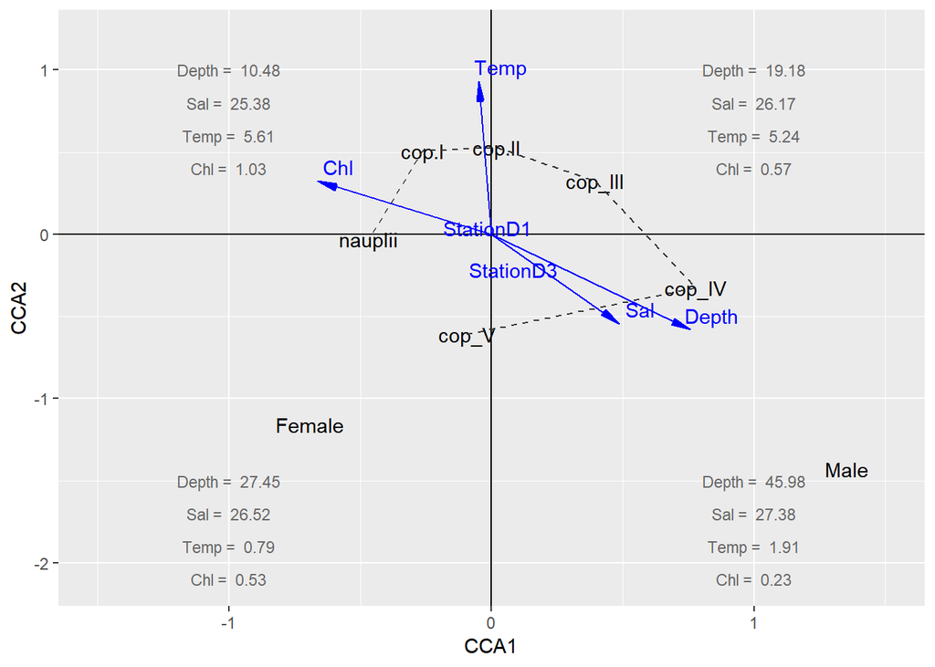

Полученная ординация позволяет выделить четыре “состояния” в популяции:

- Условия, соответствующие I квадранту: Средняя глубина, Высокая соленость, высокая температура, среднее количество хлорофилла.
- Условия, соответствующие II квадранту: Малая глубина, Низкая соленость, Высокая температура и много хлорофилла.
- Условия, соответствующие III квадранту: Средняя глубина, высокая соленость, низкая температура и средняя концентрация хлорофилла.
- Условия, соответствующие IV квадранту: Большая глубина, Высокая соленость, низкая температура, и низкое содержание хлорофилла.

По-моему, эта картинка говорит, что есть “теплый” хлорофилл, на поверхности, с ним связаны cop.I. Он маркируется положительными значениями ССА2 и отрицательными значениями ССА1. Это состояние очень короткое, наблюдается в где-то на 150-й день года (см. ниже). Есть еще и “холодный” хлорофилл (отрицательные значения ССА1 и отрицательные значения ССА2). С этим хлорофиллом связаны самки, но не самцы (!) и cop.V. Видимо, метаморфоз происходит в этих условиях, после чего самки дают науплиусов, которые поднимаются на поверхность пожрать. Обилие науплиусов видимо зависит от хлорофилла, а не от температуры (они около 0 по ССА2). Самцы же уходят в холодное, глубинное, голодное небытие. Популяция живет на “холодном” хлорофилле от 50 до 150 дня.

Если рассмотреть сезонный ход ССА1 и ССА2 (см. ниже), то становится более или менее видно, что на обеих станциях динамика похожа. То есть материал обеих станций показывает некую общую картину.

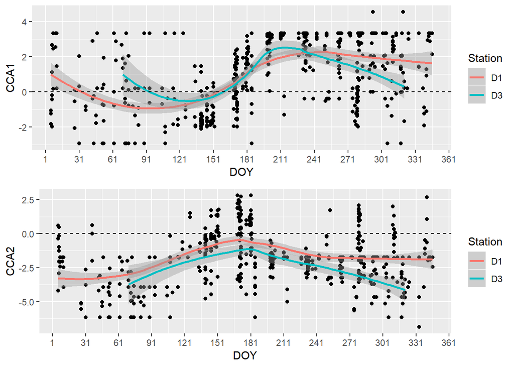

Вот еще одна визуализация. По-моему, довольно удобная. Положение дня взятия пробы относительно начала года, которое совпадает с его концом, можно охарактеризовать следующей величиной
$$Day_{position} = -cos(\frac{2 \pi DOY }{365})$$
Эта величина близка к -1 когда DOY (Day of Year) близок к 1 января (начало января, конец декабря) и равна 1 когда DOY максимально удален от него (разгар лета). Тогда можно построить ординацию описаний в осях ССА и оценить как связано положение точки в ординации с временем года. Видно, что в III и IV квадрантах популяция находится более или менее зимой, а в I и II квадрантах преимущественно летом. При этом максимальная численность популяции наблюдается как раз в районе близком ко II квадранту (то есть когда много хлорофилла).

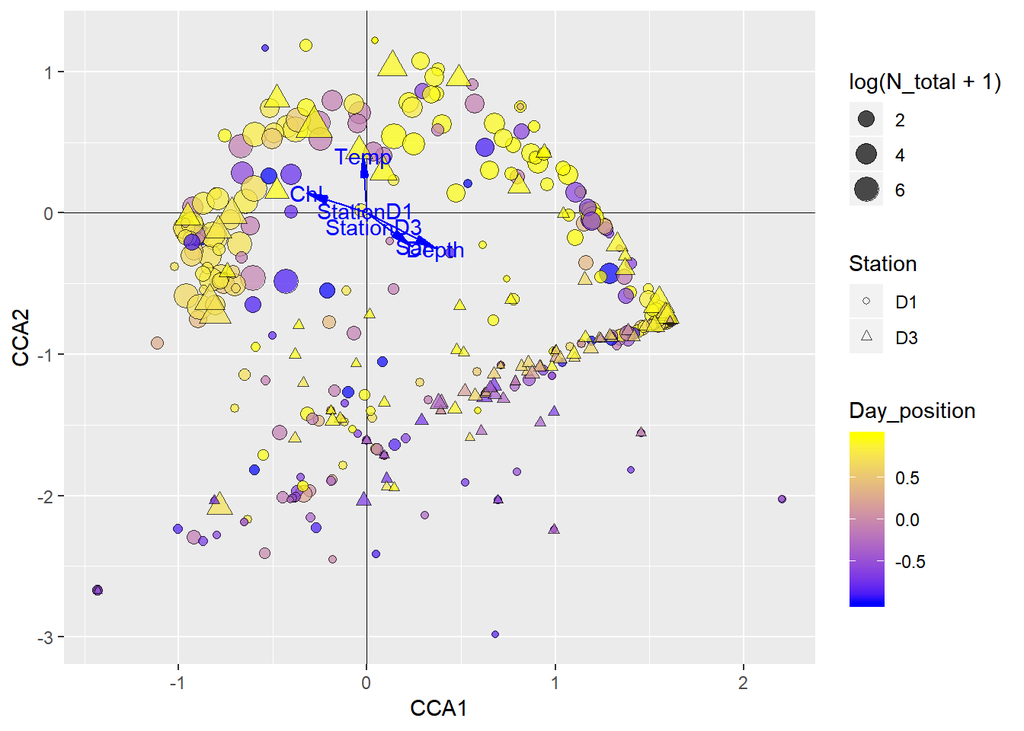

Ординация стадий и проб в осях ССА, на мой взгляд, хоть и более генерализованныя, чем те диаграммы, что были в обсуждавшемся нами тексте, да и построена на гораздо меньшем материале, но она очень информативна.